# (3) Graphs and Visualizations

# Back to main page

- Link back to main page

# Graphs and Visualizations

- The top ten busiest airports routes based on the number of flights into and out of the same airport are shown:

| Rank | N_FLIGHTS | TRIP_NAME |
| --- | --- | --- |
| 1 | 4164 | LAX SFO |
| 2 | 3576 | LGA ORD |
| 3 | 3254 | LAS LAX |
| 4 | 3158 | JFK LAX |
| 5 | 2497 | LAX SEA |
| 6 | 2405 | BOS LGA |
| 7 | 2395 | HNL OGG |
| 8 | 2376 | PDX SEA |
| 9 | 2351 | ATL MCO |
| 10 | 2293 | ATL LGA |

# Visualizing the routes

A graph of the US with the projected routes of the ten busiest flights is shown in the following graph,

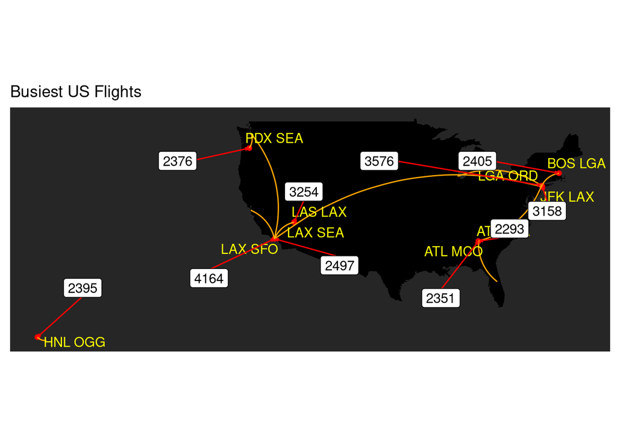

Some issues to note:

- These are not necessarily the most profitable flights.
- Several records have very few flights or tickets purchased. These are dropped from the analysis since there is not enough data to tell if they are representative. Records with tickets < 75 are removed. I feel there is not enough data on these flights to warrant a strong recommendation.

# Most profitable flights:

- The top ten most profitable flights are shown next,
- Link to compute_flightrev and compute_flightcost functions

```r
flights$REVENUE <-  compute_flightrev(flights)
flights$COSTS <- compute_flightcost(flights)
flights <-  flights %>% mutate(PROFIT = REVENUE - COSTS)
flights <-  flights %>% mutate(PROFIT = REVENUE - COSTS) %>% filter(N_TICKETS > 75,
                                                                    PROFIT > 0)
repflights <- flights
repflights$TRIP_NAME <- make_tripname(repflights)
FLIGHTS_TO_BREAKEVEN <- unlist(lapply(repflights$PROFIT, breakeven))
repflights$FLIGHTS_TO_BREAKEVEN <- FLIGHTS_TO_BREAKEVEN
repflights <-
  repflights %>% mutate(SIZE = as.numeric((ORIGIN_SIZE == 'medium_airport' &
                                             DEST_SIZE == 'medium_airport')
  ) +
    2 * as.numeric((
      ORIGIN_SIZE == 'medium_airport' &
        DEST_SIZE == 'large_airport'
    )) +
    3*as.numeric((
      ORIGIN_SIZE == 'large_airport' &
        DEST_SIZE == 'medium_airport'
    )))
repflights$SIZE <- factor(repflights$SIZE)
levels(repflights$SIZE) <- c("Large_to_Large", "Medium_to_Medium",
                             "Medium_to_Large", "Large_to_Medium")

top_profit <- repflights %>%arrange(desc(PROFIT))
top_profit <- top_profit[1:10, ]
kable(top_profit[,c("PROFIT", "TRIP_NAME", "REVENUE", "COSTS", "FLIGHTS_TO_BREAKEVEN",
                    "N_FLIGHTS", "DIST", "AVG_ITIN_FARE", "AVG_DEP_DELAY",
                    "AVG_ARR_DELAY")])
```

| PROFIT | TRIP_NAME | REVENUE | COSTS | FLIGHTS_TO_BREAKEVEN | N_FLIGHTS | DIST | AVG_ITIN_FARE | AVG_DEP_DELAY | AVG_ARR_DELAY |
| --- | --- | --- | --- | --- | --- | --- | --- | --- | --- |
| 103172.18 | DFW OGG | 153635.1 | 50462.94 | 43 | 123 | 3711 | 1154.5455 | 17.873984 | 6.2204082 |
| 99658.86 | EWR SFO | 144847.0 | 45188.17 | 44 | 1212 | 2565 | 1079.3705 | 21.497112 | 14.5354625 |
| 99273.86 | HNL IAD | 164746.3 | 65472.48 | 44 | 37 | 4817 | 1157.4129 | 2.445946 | -4.1756757 |
| 97246.78 | HNL IAH | 154100.5 | 56853.76 | 44 | 90 | 3904 | 1129.0968 | 2.177778 | -4.9550562 |
| 93001.00 | ATL HNL | 155499.9 | 62498.88 | 45 | 90 | 4502 | 1162.1761 | 7.227778 | -12.1833333 |
| 90209.50 | EWR HNL | 157050.8 | 66841.28 | 46 | 90 | 4962 | 1191.4269 | 13.983333 | 0.9157303 |
| 90054.53 | DEN OGG | 136225.4 | 46170.88 | 46 | 94 | 3302 | 1015.9840 | 11.776596 | -1.8829787 |
| 85632.90 | JFK LAX | 128996.9 | 43364.00 | 47 | 3158 | 2475 | 957.1703 | 8.546044 | -1.8903000 |
| 84127.09 | EGE EWR | 119719.3 | 35592.24 | 47 | 88 | 1725 | 912.5043 | 43.721591 | 39.4883721 |
| 81933.54 | ORD XNA | 101861.2 | 19927.68 | 48 | 528 | 522 | 750.4595 | 9.947269 | 6.8116761 |

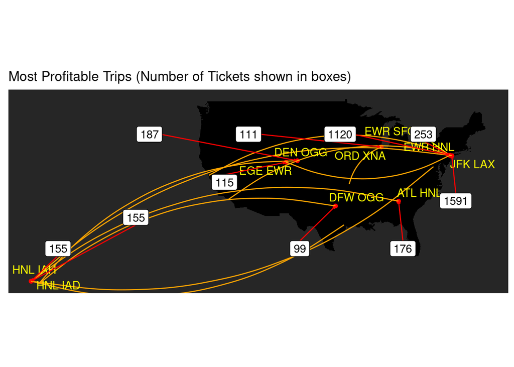

```r
top_profit <- cbind(top_profit, unpack_latlon(top_profit))

top_profit$TRIP_NAME <- make_tripname(top_profit)

ggplot() +
  geom_polygon(data = usa,
               aes(x = long, y = lat, group = group),
               fill = 'black') +
  theme(
    axis.title.x = element_blank(),
    axis.text.x = element_blank(),
    axis.ticks.x = element_blank(),
    axis.title.y = element_blank(),
    axis.text.y = element_blank(),
    axis.ticks.y = element_blank(),
    panel.grid = element_blank(),
    panel.background = element_rect("grey15")
  ) +
  ggtitle('Most Profitable Trips (Number of Tickets shown in boxes)') + coord_fixed(1.3) +
  geom_point(data = top_profit,
             aes(x = ORIGIN_LAT, y = ORIGIN_LON),
             color = 'red') + geom_curve(
               curvature = .25,
               data = top_profit,
               aes(
                 x = ORIGIN_LAT,
                 y = ORIGIN_LON,
                 xend = DEST_LAT,
                 yend = DEST_LON
               ),
               col = "orange"
             ) +
  geom_text_repel(data = top_profit,
                  aes(x = ORIGIN_LAT, y = ORIGIN_LON, label = TRIP_NAME),
                  col = "yellow") +
  geom_label_repel(
    data = top_profit,
    aes(x = ORIGIN_LAT, y = ORIGIN_LON, label = N_TICKETS),
    arrow = arrow(length = unit(.01, 'npc')),
    box.padding = unit(2.5, 'lines'),
    segment.color = "red"
  )
```

## Possible issues:

- Notice that some records show that there are less flights in the dataset than necessary flights to breakeven. This would indicate in one quarter this flight would lose money. In the long run it may be profitable but if short term gains are most important these flights should be avoided.

# Predictors of profit

The profit function is defined by $\pi(d, f, r, o_s, d_s, d_d, a_d)$, where $d$ is distance, $f$ is the fare, $r$ is the rate of occupancy, $o_s$ is the origin size, $d_s$ is the destination size, $d_d$ and $a_d$ are the delays in departure and arrival respectively. More specifically,
$$\pi(d, f, r, o_s, d_s, d_d, a_d) = r\cdot(200f + 7000 ) - 9.44 d - \mathbb{1}_{d_d > 15}\{75(d_d - 15) \} - \mathbb{1}_{a_d > 15}\{75(a_d - 15) \} - A(o_s) - A(d_s)$$
$$A(x) = \begin{cases}
10,000 &\text{ if } x = \text{Large} \\
5,000 & \text{otherwise.}
\end{cases}$$

- $d_d$ is departure delay time in minutes.
- $a_d$ is arrival delay time in minutes.
- $_{d_i} is an indicator function which is 1 if delay or arrival time is greater than 15 minutes.
- Given that this is a linear function in its parameters and estimating supply and demand equations were futile, nonlinear optimization of the profit function is not possible.
- The most profitable flights will depend linearly on distance, rate, and fare. While airport size is import given that it enters the equation merely as a constant its only effect will be in the way in which it interacts with the other variables. As it will be shown later merely minimizing airport costs is not a viable solution for maximizing profit.
- Fare depends positively on distance. While distance enters the profit equation as a negative multiplier, fare increases with distance which positively affects profit.
- The positive effect of distance appears to overcome its negative multiplier in profit which is shown below. Some of the most profitable flights are the longer distance flights.
- The airport size of origin and destination flights is used to break down the data categorically. Consistently the highest profit flights are to and from larger airports. Medium to medium are less profitable. However, when controlling for other factors in a multiple regression the partial effect on profit does reveal an increase in profit (of about 10,000). Yet this is not very surprising given that the partial effect should be around 10,000 dollars as the profit function penalizes large airports by an extra 5,000 on each airport. For this airline, it is my opinion the total of profit is more important than marginal effects. The regression results are shown below,

```r
summary(lm(PROFIT ~ N_FLIGHTS + DIST + AVG_ITIN_FARE + SIZE + AVG_ARR_DELAY + AVG_DEP_DELAY, data = repflights))
```

```
##
## Call:
## lm(formula = PROFIT ~ N_FLIGHTS + DIST + AVG_ITIN_FARE + SIZE +
##     AVG_ARR_DELAY + AVG_DEP_DELAY, data = repflights)
##
## Residuals:
##      Min       1Q   Median       3Q      Max
## -10342.7   -593.9     -6.9    590.5  24197.6
##
## Coefficients:
##                        Estimate Std. Error  t value Pr(>|t|)
## (Intercept)          -1.477e+04  1.628e+02  -90.734  < 2e-16 ***
## N_FLIGHTS             8.277e-02  9.281e-02    0.892   0.3726
## DIST                 -9.361e+00  7.836e-02 -119.469  < 2e-16 ***
## AVG_ITIN_FARE         1.296e+02  3.749e-01  345.727  < 2e-16 ***
## SIZEMedium_to_Medium  9.894e+03  4.320e+02   22.901  < 2e-16 ***
## SIZEMedium_to_Large   4.831e+03  1.321e+02   36.568  < 2e-16 ***
## SIZELarge_to_Medium   4.689e+03  1.608e+02   29.155  < 2e-16 ***
## AVG_ARR_DELAY        -2.274e+01  1.155e+01   -1.969   0.0491 *
## AVG_DEP_DELAY        -5.776e+01  1.317e+01   -4.384 1.24e-05 ***
## ---
## Signif. codes:  0 '***' 0.001 '**' 0.01 '*' 0.05 '.' 0.1 ' ' 1
##
## Residual standard error: 1516 on 1693 degrees of freedom
## Multiple R-squared:  0.9876, Adjusted R-squared:  0.9876
## F-statistic: 1.692e+04 on 8 and 1693 DF,  p-value: < 2.2e-16
```

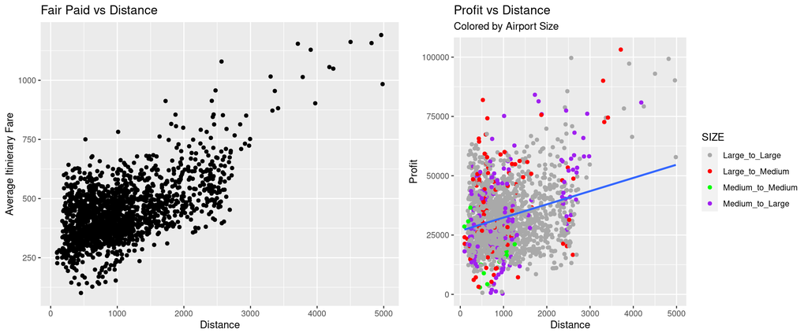

- This indicates that longer flights are more profitable making it a key characteristic for profitability. However, it is not the most important characteristic. **The most important is high fare price. This difference is summarized in the following two plots:**

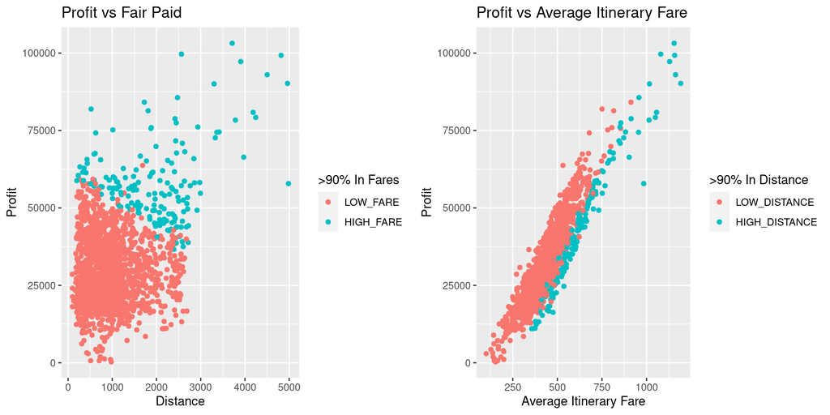

- The plot on the left shows that profit and distance are positively linearly related. However, when controlling for fare price there are high profit flights that are short and long. This is most clearly shown in the following regression results. When the regression,
  $$\pi = c + \beta d + \varepsilon,$$
  where $c$ is a constant, $d$ is distance and $\varepsilon$ is the idiosyncratic error with the usual distributional assumptions the multiplier $\beta$ is positive 5.6. However, when controling for the fare and other factors (included in $X$ and regression results are shown above),
  $$\pi = c + \beta d + \gamma X + \varepsilon,$$
  the multiplier on distance is -9.4. Fare is clearly more important than distance. Longer distance flights should only be tolerated if the increase in fare justifies the profit bottom line, in many cases it does.
- Airport size is another important factor for profit. Strictly looking at the median profit shows that it is increased at larger airports. Roundtrip routes between medium airports did not command high fees in this dataset, although the regression results showed positive marginal effects of smaller airports. Summary plots of these statistics are shown next,

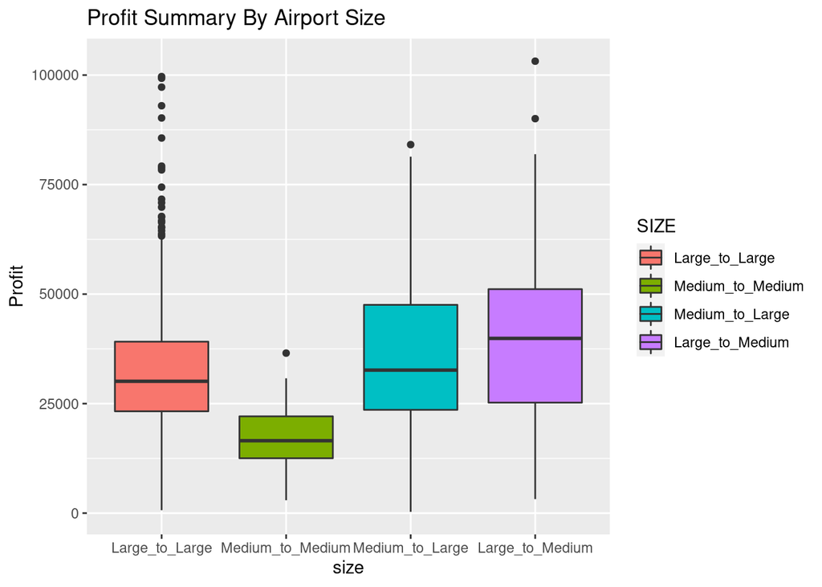

| SIZE | Min | Q1 | Median | Avg | Q3 | Max |
| --- | --- | --- | --- | --- | --- | --- |
| Large_to_Medium | 3199.9686 | 25227.37 | 39887.55 | 39411.54 | 51128.96 | 103172.18 |
| Medium_to_Large | 293.8963 | 23583.98 | 32647.65 | 35304.66 | 47548.91 | 84127.09 |
| Large_to_Large | 672.2845 | 23251.57 | 30098.38 | 32088.10 | 39140.63 | 99658.86 |
| Medium_to_Medium | 2942.9034 | 12527.62 | 16529.94 | 17838.49 | 22095.29 | 36528.99 |

- The most profitable flights in the dataset are longer flights since they come with offsetting high fees for fares.
- Delays obviously have a negative impact on profit. Flights with lower delays will increase profit. However, very profitable flights also have delays, and this should by no means discourage the airline from entering these routes. A investigation into the effect of delays turned up that delays are mainly negligible on profits. The scatter plots show very little impact of delays, and regression results show a statistically significant impact of delays that is not financially meaningful.

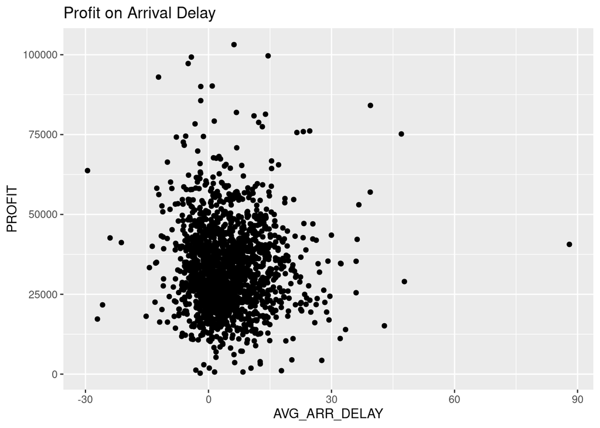

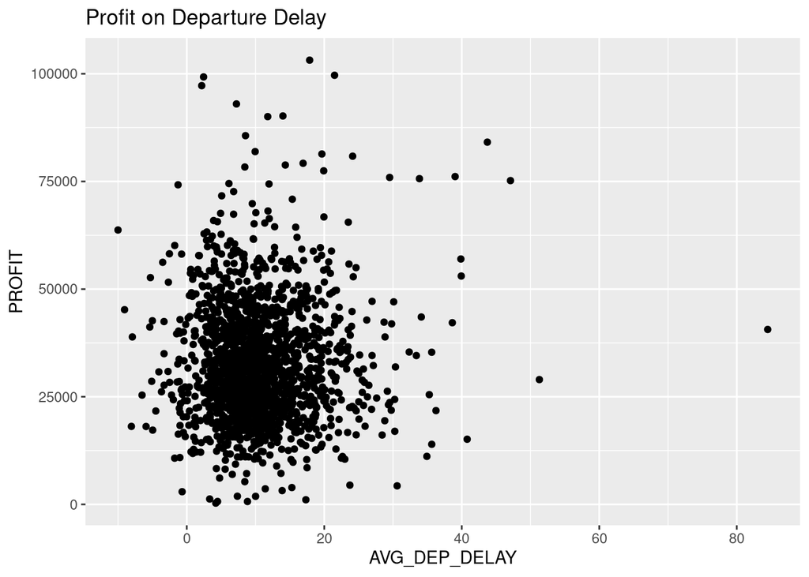

# Breakeven flights

Breakeven number of flights is another important consideration. Profit is nonlinearly related to this quantity. From the plot of breakeven flights on profit this is clear,

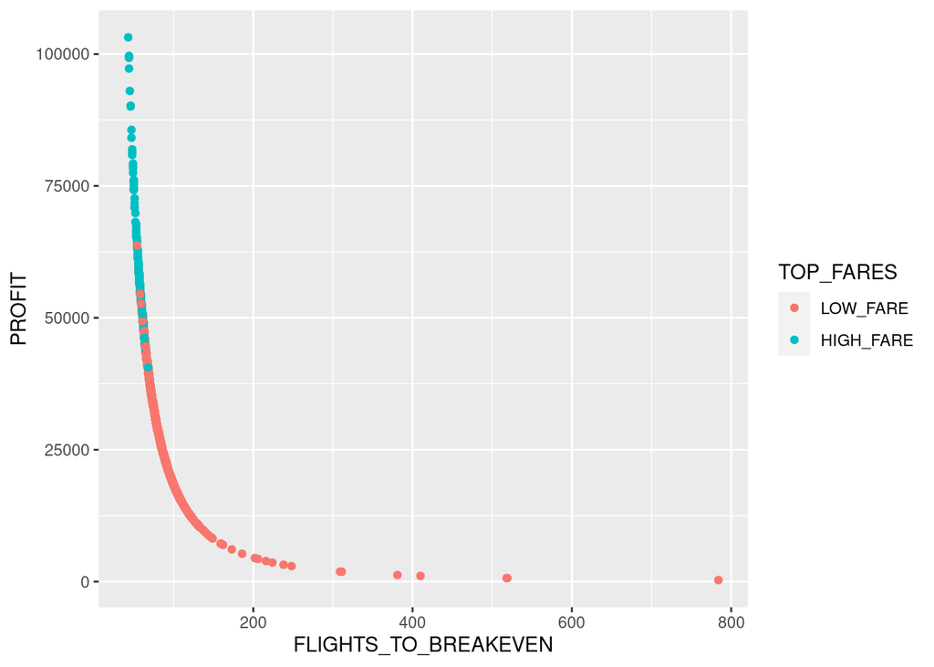

This function can be estimated by noting that the data transformation of the regression equation allows one to estimate the nonlinear exponent on $x$. Note that,
$$y = c + \beta x^\gamma + \varepsilon$$
and therefore,
$$log(y) = c^* + \gamma x + \varepsilon$$
where $c^*$ will be some interaction of $\beta$ and the constant. The regression equation returned that the appropriate $\gamma$ is $-2.02$ and the multiplier is 19.13.

```
##
## Call:
## lm(formula = log(PROFIT) ~ log(FLIGHTS_TO_BREAKEVEN), data = repflights)
##
## Residuals:
##        Min         1Q     Median         3Q        Max
## -0.0155003 -0.0065211 -0.0000879  0.0062641  0.0302301
##
## Coefficients:
##                            Estimate Std. Error t value Pr(>|t|)
## (Intercept)               19.132291   0.003552    5387   <2e-16 ***
## log(FLIGHTS_TO_BREAKEVEN) -2.022365   0.000812   -2491   <2e-16 ***
## ---
## Signif. codes:  0 '***' 0.001 '**' 0.01 '*' 0.05 '.' 0.1 ' ' 1
##
## Residual standard error: 0.007989 on 1700 degrees of freedom
## Multiple R-squared:  0.9997, Adjusted R-squared:  0.9997
## F-statistic: 6.203e+06 on 1 and 1700 DF,  p-value: < 2.2e-16
```

This gives,
$$\hat{y} = e^{19.13}\times x^{-2.02}$$
This fits the data quite well. The black line is the fitted equation for the data,

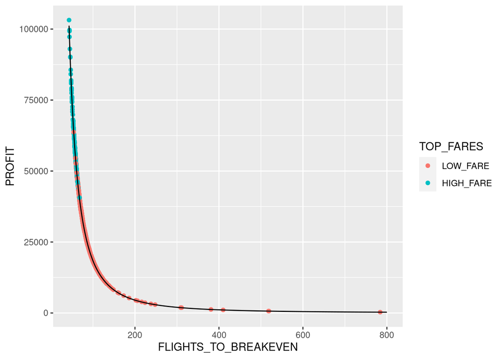

This equation is interesting. It shows that there are huge profit gains around the flights that take fewer than 100 flights. In fact, since the derivative of this equation gives,
$$\frac{dy}{dx} = \frac{-\gamma e^{19.13}}{x^{3.022}}$$
this implies that if it took 50 flight to breakeven a change of just one flight impacts profit by $3,016.80. And since the effect is highly nonlinear the effect impacts profit greatly in the region less than 100 flights but profit is not changed much if the number of flights to break even is much greater than 100. **This underscores the importance of searching for flights which have a low number of flights to breakeven as the impact on profit is immense by minimizing this quantity.**

# Recommendations

- Link to next step, Recommendations